# Women’s Political Empowerment Index, 2025

## Ranking of all countries

Horizontal bars, ordered from highest to lowest index. The dashed line marks the **0.5 (50%) threshold**. Asia-Pacific countries (ESCAP members, as defined above) are in green; all other countries are in light purple.

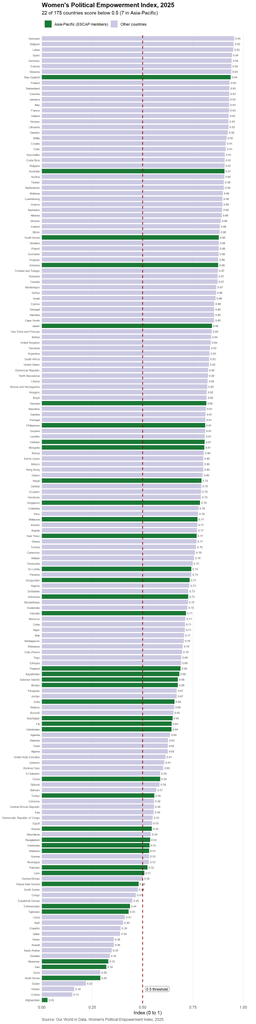

```r
rank_df <- dat |>
  mutate(group = ifelse(Code %in% ap_codes, "Asia-Pacific (ESCAP members)", "Other countries"))

n_below  <- sum(rank_df$index < 0.5)
n_ap_below <- sum(rank_df$index < 0.5 & rank_df$group != "Other countries")

ggplot(rank_df, aes(x = index, y = reorder(Entity, index), fill = group)) +
  geom_col(width = 0.8) +
  geom_text(aes(label = sprintf("%.2f", index)), hjust = -0.2, size = 2.2, colour = "grey25") +
  geom_vline(xintercept = 0.5, linetype = "dashed", linewidth = 0.8, colour = "darkred") +
  annotate("label", x = 0.5, y = 3, label = "0.5 threshold", size = 3, fill = "white",
           label.size = 0, hjust = -0.1) +
  scale_fill_manual(values = c("Asia-Pacific (ESCAP members)" = "#1b7837",
                               "Other countries"              = "#cbc9e2"),
                    name = NULL) +
  scale_x_continuous(limits = c(0, 1.05), breaks = seq(0, 1, 0.25), expand = c(0, 0)) +
  labs(title = "Women's Political Empowerment Index, 2025",
       subtitle = paste0(n_below, " of ", nrow(rank_df), " countries score below 0.5 (",
                         n_ap_below, " in Asia-Pacific)"),
       x = "Index (0 to 1)", y = NULL,
       caption = "Source: Our World in Data, Women's Political Empowerment Index, 2025.") +
  theme_minimal(base_size = 11) +
  theme(panel.grid.major.y = element_blank(), panel.grid.minor = element_blank(),
        axis.text.y = element_text(size = 6.5),
        legend.position = "top", legend.justification = "left",
        plot.title = element_text(face = "bold", size = 14),
        plot.caption = element_text(colour = "grey35", hjust = 0),
        plot.background = element_rect(fill = "white", colour = NA))
```

## Ranking in Asia- Pacific

We also changed the ordering of the bar **from lowest to highest** index. The dashed line marks the **0.5 (50%) threshold**. Asia-Pacific countries only.

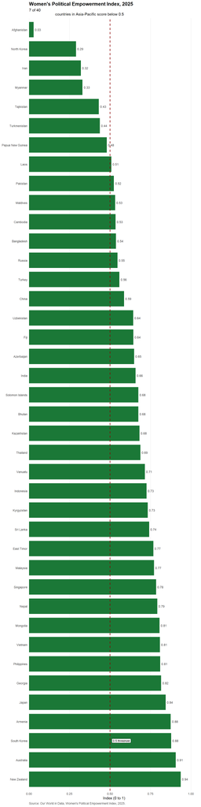

```r
rank_df_AP <- dat %>%
  filter(Code %in% ap_codes)
  # mutate(group = ifelse(Code %in% ap_codes, "Asia-Pacific (ESCAP members)", "Other countries"))
  # n_below  <- sum(rank_df$index < 0.5)
  # n_ap_below <- sum(rank_df$index < 0.5 & rank_df$group != "Other countries")


rank_df_AP %>%
  ggplot() +
  aes(x = index, y = reorder(Entity, -index)) +
  geom_col(width = 0.8, fill = "#1b7837") +
  geom_text(aes(label = sprintf("%.2f", index)), hjust = -0.2, size = 3.2, colour = "grey25") +
  geom_vline(xintercept = 0.5, linetype = "dashed", linewidth = 0.8, colour = "darkred") +
  annotate("label", x = 0.5, y = 3, label = "0.5 threshold", size = 3, fill = "white",
           label.size = 0, hjust = -0.1) +
  scale_x_continuous(limits = c(0, 1.05),
                     breaks = seq(0, 1, 0.25), expand = c(0, 0)) +
  labs(title = "Women's Political Empowerment Index, 2025",
       subtitle = paste0(n_ap_below, " of ", nrow(rank_df_AP),"
                         countries in Asia-Pacific score below 0.5"),
       x = "Index (0 to 1)",
       y = NULL,
       caption = "Source: Our World in Data, Women's Political Empowerment Index, 2025.") +
  theme_minimal(base_size = 11) +
  theme(panel.grid.major.y = element_blank(), panel.grid.minor = element_blank(),
        axis.text.y = element_text(size = 8.5),
        legend.position = "top", legend.justification = "left",
        plot.title = element_text(face = "bold", size = 14),
        plot.caption = element_text(colour = "grey35", hjust = 0),
        plot.background = element_rect(fill = "white", colour = NA))
```

# New geometries

## Hex Maps

Hex maps replace geographic areas with **equal-sized** hexagons arranged to preserve the approximate location of regions. They reduce the visual dominance of large areas and make comparisons across regions clearer and more balanced, while dramatically **removing the size and geometries** of the countries.

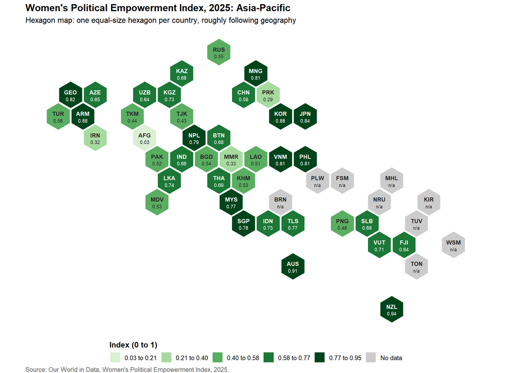

```r
# Hand-made hex layout for the 49 ESCAP members: pointy-top hexes, odd rows shifted half a cell right.
# col = west -> east, row = north -> south. Edit the table to move a country.
hex_layout <- tribble(
  ~Code, ~col, ~row,
  "RUS",  7, 0,
  "KAZ",  5, 1,  "MNG",  8, 1,
  "GEO",  1, 2,  "AZE",  2, 2,  "UZB",  4, 2,  "KGZ",  5, 2,  "CHN",  8, 2,  "PRK",  9, 2,
  "TUR",  0, 3,  "ARM",  1, 3,  "TKM",  3, 3,  "TJK",  5, 3,  "KOR",  9, 3,  "JPN", 10, 3,
  "IRN",  2, 4,  "AFG",  4, 4,  "NPL",  6, 4,  "BTN",  7, 4,
  "PAK",  4, 5,  "IND",  5, 5,  "BGD",  6, 5,  "MMR",  7, 5,  "LAO",  8, 5,  "VNM",  9, 5,  "PHL", 10, 5,
  "LKA",  5, 6,  "THA",  7, 6,  "KHM",  8, 6,  "PLW", 11, 6,  "FSM", 12, 6,  "MHL", 14, 6,
  "MDV",  4, 7,  "MYS",  7, 7,  "BRN",  9, 7,  "NRU", 13, 7,  "KIR", 15, 7,
  "SGP",  8, 8,  "IDN",  9, 8,  "TLS", 10, 8,  "PNG", 12, 8,  "SLB", 13, 8,  "TUV", 15, 8,
  "VUT", 13, 9,  "FJI", 14, 9,  "WSM", 16, 9,
  "AUS", 10, 10, "TON", 15, 10,
  "NZL", 14, 12
)
stopifnot(setequal(hex_layout$Code, ap_codes), !anyDuplicated(hex_layout[c("col", "row")]))

# Hexagon outlines (circumradius 1/sqrt(3) makes neighbouring cell centres 1 apart; x0.95 leaves a gap)
R   <- 0.95 / sqrt(3)
ang <- pi / 180 * (30 + 60 * 0:5)

hexes <- hex_layout |>
  mutate(cx = col + 0.5 * (row %% 2),                     # odd rows shifted right
         cy = -row * sqrt(3) / 2) |>
  left_join(select(dat, Code, index), by = "Code") |>
  mutate(cls = classify(index, br_equal),                 # same global equal-interval classes as Map 3
         txt = ifelse(!is.na(cls) & as.integer(cls) >= 4, "white", "grey15"))

polys <- hexes[rep(seq_len(nrow(hexes)), each = 6), ] |>
  mutate(vertex = rep(1:6, times = nrow(hexes)),
         px = cx + R * cos(ang[vertex]),
         py = cy + R * sin(ang[vertex]))

p <-polys %>%
ggplot() +
  geom_polygon(aes(px, py, group = Code, fill = cls),
               colour = "white", linewidth = 0.4) +
  geom_text(data = hexes, aes(cx, cy + 0.11, label = Code, colour = txt),
            fontface = "bold", size = 3.1) +
  geom_text(data = hexes, aes(cx, cy - 0.17, label = ifelse(is.na(index), "n/a", sprintf("%.2f", index)), colour = txt),
            size = 2.7) +
  scale_fill_manual(values = greens, na.value = "grey80", drop = FALSE, na.translate = TRUE,
                    labels = function(x) ifelse(is.na(x), "No data", x),
                    name = "Index (0 to 1)",
                    guide = guide_legend(nrow = 1, title.position = "top")) +
  scale_colour_identity() +
  coord_equal() +
  labs(title = "Women's Political Empowerment Index, 2025: Asia-Pacific",
       subtitle = "Hexagon map: one equal-size hexagon per country, roughly following geography",
       caption = "Source: Our World in Data, Women's Political Empowerment Index, 2025.") +
  theme_void(base_size = 12) +
  theme(plot.background = element_rect(fill = "white", colour = NA),
        legend.position = "bottom", legend.title = element_text(face = "bold"),
        plot.title = element_text(face = "bold", size = 15),
        plot.caption = element_text(colour = "grey35", hjust = 0))

p
```

```r
# library(plotly)
# plotly::ggplotly(p)
```

## Hex map with inverted index

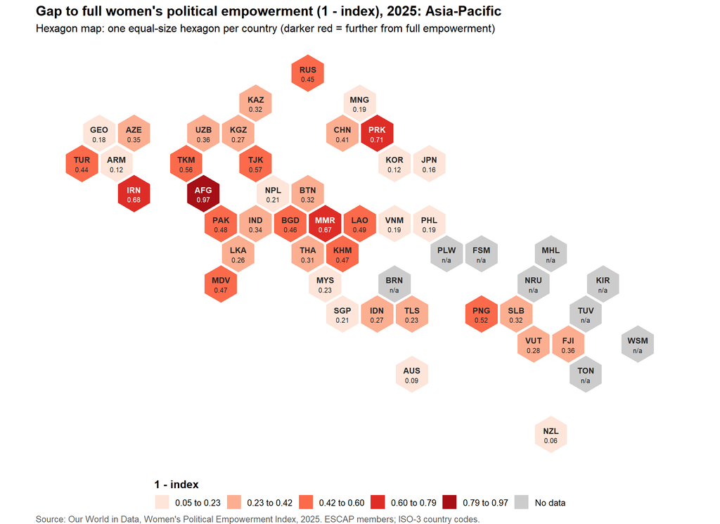

```r
# Uses hex_layout, R and ang from the hex map chunk (map-ap-hex)
br_gap <- 1 - rev(br_equal)                               # global equal-interval breaks of the index, mirrored
reds   <- c("#fee5d9", "#fcae91", "#fb6a4a", "#de2d26", "#a50f15")

hexes_gap <- hex_layout |>
  mutate(cx = col + 0.5 * (row %% 2),                     # odd rows shifted right
         cy = -row * sqrt(3) / 2) |>
  left_join(select(dat, Code, index), by = "Code") |>
  mutate(gap = 1 - index,                                 # distance from full empowerment (0 = best)
         cls = classify(gap, br_gap),
         txt = ifelse(!is.na(cls) & as.integer(cls) >= 4, "white", "grey15"))

polys_gap <- hexes_gap[rep(seq_len(nrow(hexes_gap)), each = 6), ] |>
  mutate(vertex = rep(1:6, times = nrow(hexes_gap)),
         px = cx + R * cos(ang[vertex]),
         py = cy + R * sin(ang[vertex]))

ggplot() +
  geom_polygon(data = polys_gap, aes(px, py, group = Code, fill = cls),
               colour = "white", linewidth = 0.4) +
  geom_text(data = hexes_gap, aes(cx, cy + 0.11, label = Code, colour = txt),
            fontface = "bold", size = 3.1) +
  geom_text(data = hexes_gap, aes(cx, cy - 0.17, label = ifelse(is.na(gap), "n/a", sprintf("%.2f", gap)), colour = txt),
            size = 2.7) +
  scale_fill_manual(values = reds, na.value = "grey80", drop = FALSE, na.translate = TRUE,
                    labels = function(x) ifelse(is.na(x), "No data", x),
                    name = "1 - index",
                    guide = guide_legend(nrow = 1, title.position = "top")) +
  scale_colour_identity() +
  coord_equal() +
  labs(title = "Gap to full women's political empowerment (1 - index), 2025: Asia-Pacific",
       subtitle = "Hexagon map: one equal-size hexagon per country (darker red = further from full empowerment)",
       caption = "Source: Our World in Data, Women's Political Empowerment Index, 2025. ESCAP members; ISO-3 country codes.") +
  theme_void(base_size = 12) +
  theme(plot.background = element_rect(fill = "white", colour = NA),
        legend.position = "bottom", legend.title = element_text(face = "bold"),
        plot.title = element_text(face = "bold", size = 15),
        plot.caption = element_text(colour = "grey35", hjust = 0))
```

## Dorling

The Dorling map, a special type of thematic map for visualizing geospatial statistical data. It transforms regions into circles with areas proportionate to statistical values while *endeavoring* to maintain regional spatial relationships.

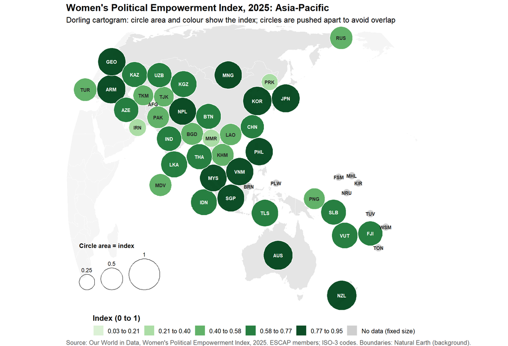

```r
# 1. Start positions: one anchor per country (inside its largest polygon part)
dor <- ap_data |>
  st_cast("POLYGON") |>
  suppressWarnings() |>
  mutate(part_m2 = as.numeric(st_area(geometry))) |>
  group_by(Code) |>
  slice_max(part_m2, n = 1, with_ties = FALSE) |>
  ungroup() |>
  st_point_on_surface() |>
  suppressWarnings()
xy  <- st_coordinates(dor)
dor <- dor |>
  st_drop_geometry() |>
  transmute(Code, index, x0 = xy[, "X"], y0 = xy[, "Y"])

# 2. Circle radius: AREA proportional to the index (radius ~ sqrt(index)).
#    Countries without data get a small fixed circle (grey) so every member is shown.
r_max <- 7.5e5                                   # radius (metres) for an index of 1
dor$r <- ifelse(is.na(dor$index), 0.25 * r_max, r_max * sqrt(dor$index))

# 3. Dorling algorithm: push overlapping circles apart, while a weak spring
#    pulls each circle back toward its true location
dorling <- function(x0, y0, r, xlim, ylim, iter = 400, pad = 2e4, step = 0.5, spring = 0.02) {
  x <- x0; y <- y0
  for (it in seq_len(iter)) {
    dx <- outer(x, x, "-"); dy <- outer(y, y, "-")
    d  <- sqrt(dx^2 + dy^2); diag(d) <- Inf
    ov <- pmax(outer(r, r, "+") + pad - d, 0)    # overlap between each pair
    x  <- x + step * rowSums(dx / d * ov) / 2 + spring * (x0 - x)
    y  <- y + step * rowSums(dy / d * ov) / 2 + spring * (y0 - y)
    x  <- pmin(pmax(x, xlim[1] + r), xlim[2] - r)   # keep circles inside the map frame
    y  <- pmin(pmax(y, ylim[1] + r), ylim[2] - r)
  }
  tibble(x = x, y = y)
}
dor <- bind_cols(dor, dorling(dor$x0, dor$y0, dor$r, ap_window$x, ap_window$y))

# 4. Classes (same global equal-interval classes and green scale as Map 3), labels, draw order
dor <- dor |>
  mutate(cls = classify(index, br_equal),
         txt = ifelse(!is.na(cls) & as.integer(cls) >= 4, "white", "grey15")) |>
  arrange(desc(r))                               # big circles first, small ones on top

# 5. Circle outlines as polygons, so circles stay true circles in map units
th <- seq(0, 2 * pi, length.out = 61)[-61]
circle_poly <- function(x, y, r, id) tibble(id = id, px = x + r * cos(th), py = y + r * sin(th))
circles <- bind_rows(Map(circle_poly, dor$x, dor$y, dor$r, dor$Code)) |>
  left_join(select(dor, Code, cls), by = c("id" = "Code"))

# Reference circles for the size legend (lower left)
leg_v   <- c(0.25, 0.5, 1)
leg_r   <- r_max * sqrt(leg_v)
leg_x   <- ap_window$x[1] + 1.0e6 + cumsum(c(0, leg_r[-3] + leg_r[-1] + 3e5))
leg_y   <- ap_window$y[1] + 1.0e6 + leg_r
leg_poly <- bind_rows(Map(circle_poly, leg_x, leg_y, leg_r, as.character(leg_v)))

ggplot() +
  geom_sf(data = ap_ctx,  fill = "grey96", colour = "white", linewidth = 0.15) +
  geom_sf(data = ap_data, fill = "grey90", colour = "white", linewidth = 0.15) +
  geom_polygon(data = circles, aes(px, py, group = id, fill = cls),
               colour = "white", linewidth = 0.4, alpha = 0.95) +
  geom_text(data = dor, aes(x, y, label = Code, colour = txt), fontface = "bold", size = 2.6) +
  # size legend
  geom_polygon(data = leg_poly, aes(px, py, group = id), fill = NA, colour = "grey30", linewidth = 0.4) +
  annotate("text", x = leg_x, y = leg_y + leg_r + 2.2e5, label = leg_v, size = 3) +
  annotate("text", x = leg_x[1] - leg_r[1], y = max(leg_y + leg_r) + 6.5e5,
           label = "Circle area = index", hjust = 0, fontface = "bold", size = 3.4) +
  scale_fill_manual(values = greens, na.value = "grey80", drop = FALSE, na.translate = TRUE,
                    labels = function(x) ifelse(is.na(x), "No data (fixed size)", x),
                    name = "Index (0 to 1)",
                    guide = guide_legend(nrow = 1, title.position = "top")) +
  scale_colour_identity() +
  coord_sf(xlim = ap_window$x, ylim = ap_window$y, expand = FALSE) +
  labs(title = "Women's Political Empowerment Index, 2025: Asia-Pacific",
       subtitle = "Dorling cartogram: circle area and colour show the index; circles are pushed apart to avoid overlap",
       caption = "Source: Our World in Data, Women's Political Empowerment Index, 2025. ESCAP members; ISO-3 codes. Boundaries: Natural Earth (background).") +
  map_theme
```

### Dorling with inverted index

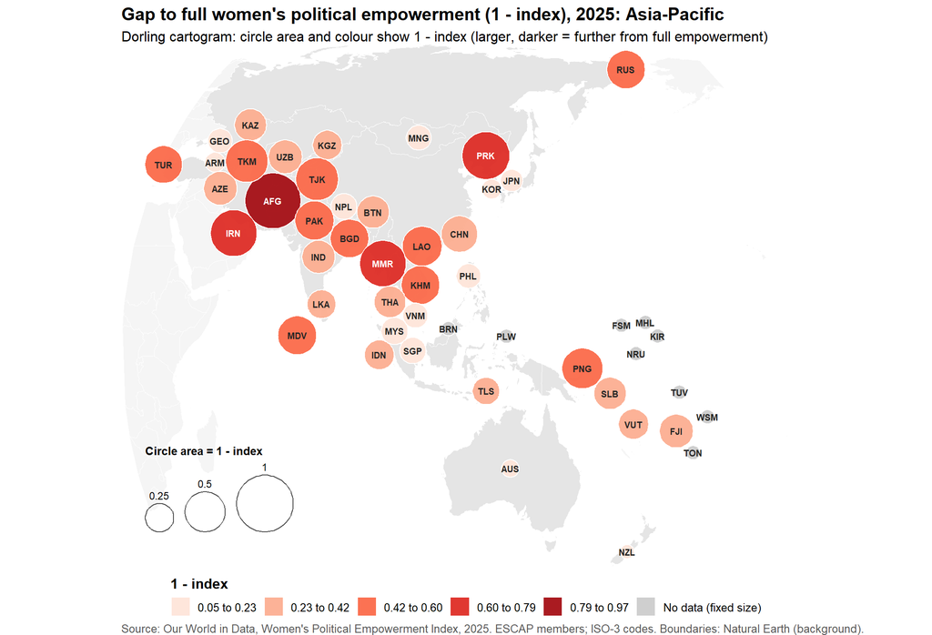

```r
# Uses dorling() and circle_poly() from the Dorling map chunk (map-ap-dorling)
br_gap <- 1 - rev(br_equal)                               # global equal-interval breaks of the index, mirrored
reds   <- c("#fee5d9", "#fcae91", "#fb6a4a", "#de2d26", "#a50f15")

# 1. Start positions: one anchor per country (inside its largest polygon part)
dor_g <- ap_data |>
  st_cast("POLYGON") |>
  suppressWarnings() |>
  mutate(part_m2 = as.numeric(st_area(geometry))) |>
  group_by(Code) |>
  slice_max(part_m2, n = 1, with_ties = FALSE) |>
  ungroup() |>
  st_point_on_surface() |>
  suppressWarnings()
xy_g  <- st_coordinates(dor_g)
dor_g <- dor_g |>
  st_drop_geometry() |>
  transmute(Code, gap = 1 - index, x0 = xy_g[, "X"], y0 = xy_g[, "Y"])

# 2. Circle radius: AREA proportional to 1 - index (radius ~ sqrt(gap)); no-data countries: small fixed grey circle
r_max_g <- 7.5e5                                          # radius (metres) for a gap of 1
dor_g$r <- ifelse(is.na(dor_g$gap), 0.25 * r_max_g, r_max_g * sqrt(dor_g$gap))

# 3. Push overlapping circles apart (weak spring back to true location, kept inside the map frame)
dor_g <- bind_cols(dor_g, dorling(dor_g$x0, dor_g$y0, dor_g$r, ap_window$x, ap_window$y))

# 4. Classes, labels, draw order
dor_g <- dor_g |>
  mutate(cls = classify(gap, br_gap),
         txt = ifelse(!is.na(cls) & as.integer(cls) >= 4, "white", "grey15")) |>
  arrange(desc(r))                                        # big circles first, small ones on top

# 5. Circle outlines as polygons, so circles stay true circles in map units
circles_g <- bind_rows(Map(circle_poly, dor_g$x, dor_g$y, dor_g$r, dor_g$Code)) |>
  left_join(select(dor_g, Code, cls), by = c("id" = "Code"))

# Reference circles for the size legend (lower left)
leg_v    <- c(0.25, 0.5, 1)
leg_r    <- r_max_g * sqrt(leg_v)
leg_x    <- ap_window$x[1] + 1.0e6 + cumsum(c(0, leg_r[-3] + leg_r[-1] + 3e5))
leg_y    <- ap_window$y[1] + 1.0e6 + leg_r
leg_poly <- bind_rows(Map(circle_poly, leg_x, leg_y, leg_r, as.character(leg_v)))

ggplot() +
  geom_sf(data = ap_ctx,  fill = "grey96", colour = "white", linewidth = 0.15) +
  geom_sf(data = ap_data, fill = "grey90", colour = "white", linewidth = 0.15) +
  geom_polygon(data = circles_g, aes(px, py, group = id, fill = cls),
               colour = "white", linewidth = 0.4, alpha = 0.95) +
  geom_text(data = dor_g, aes(x, y, label = Code, colour = txt), fontface = "bold", size = 2.6) +
  # size legend
  geom_polygon(data = leg_poly, aes(px, py, group = id), fill = NA, colour = "grey30", linewidth = 0.4) +
  annotate("text", x = leg_x, y = leg_y + leg_r + 2.2e5, label = leg_v, size = 3) +
  annotate("text", x = leg_x[1] - leg_r[1], y = max(leg_y + leg_r) + 6.5e5,
           label = "Circle area = 1 - index", hjust = 0, fontface = "bold", size = 3.4) +
  scale_fill_manual(values = reds, na.value = "grey80", drop = FALSE, na.translate = TRUE,
                    labels = function(x) ifelse(is.na(x), "No data (fixed size)", x),
                    name = "1 - index",
                    guide = guide_legend(nrow = 1, title.position = "top")) +
  scale_colour_identity() +
  coord_sf(xlim = ap_window$x, ylim = ap_window$y, expand = FALSE) +
  labs(title = "Gap to full women's political empowerment (1 - index), 2025: Asia-Pacific",
       subtitle = "Dorling cartogram: circle area and colour show 1 - index (larger, darker = further from full empowerment)",
       caption = "Source: Our World in Data, Women's Political Empowerment Index, 2025. ESCAP members; ISO-3 codes. Boundaries: Natural Earth (background).") +
  map_theme
```

## Cartogram

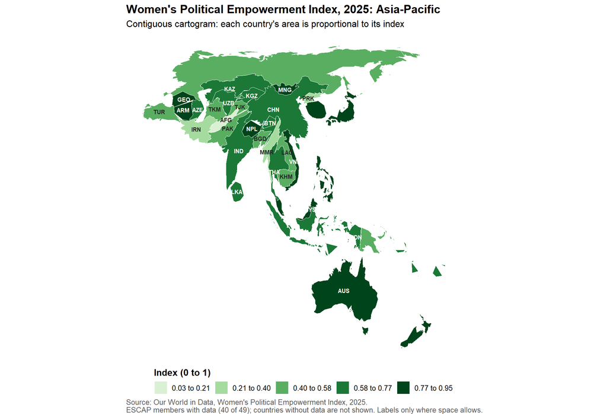

```r
library(cartogram)

# One feature per country (some come in several pieces), only those with data;
# simplified outlines keep the cartogram algorithm fast and stable
carto_in <- ap_data |>
  filter(!is.na(index)) |>
  group_by(Code, Entity, index) |>
  summarise(.groups = "drop") |>
  st_make_valid() |>
  st_simplify(dTolerance = 2e4, preserveTopology = TRUE)

# Contiguous (Dougenik) cartogram: each country's AREA is made proportional to its index
carto <- cartogram_cont(carto_in, weight = "index", itermax = 15, maxSizeError = 1.3)

carto <- carto |>
  mutate(cls = classify(index, br_equal))                 # same global equal-interval classes as Map 3

# Labels: one point inside the largest part of each deformed country, only where there is room
lab <- carto |>
  st_cast("POLYGON") |>
  suppressWarnings() |>
  mutate(part_m2 = as.numeric(st_area(geometry))) |>
  group_by(Code) |>
  slice_max(part_m2, n = 1, with_ties = FALSE) |>
  ungroup() |>
  filter(part_m2 > 1.5e11) |>                             # label countries larger than ~150,000 km2 on the map
  st_point_on_surface() |>
  suppressWarnings()
lab_xy <- st_coordinates(lab)
lab <- lab |>
  st_drop_geometry() |>
  mutate(x = lab_xy[, "X"], y = lab_xy[, "Y"],
         txt = ifelse(as.integer(cls) >= 4, "white", "grey15"))

ggplot() +
  geom_sf(data = carto, aes(fill = cls), colour = "white", linewidth = 0.25) +
  geom_text(data = lab, aes(x, y, label = Code, colour = txt), fontface = "bold", size = 2.6) +
  scale_fill_manual(values = greens, drop = FALSE,
                    name = "Index (0 to 1)",
                    guide = guide_legend(nrow = 1, title.position = "top")) +
  scale_colour_identity() +
  labs(title = "Women's Political Empowerment Index, 2025: Asia-Pacific",
       subtitle = "Contiguous cartogram: each country's area is proportional to its index",
       caption = paste0("Source: Our World in Data, Women's Political Empowerment Index, 2025.\n",
                        "ESCAP members with data (", nrow(carto), " of ", length(ap_codes),
                        "); countries without data are not shown. Labels only where space allows.")) +
  map_theme
```

### Cartogram with inverted index

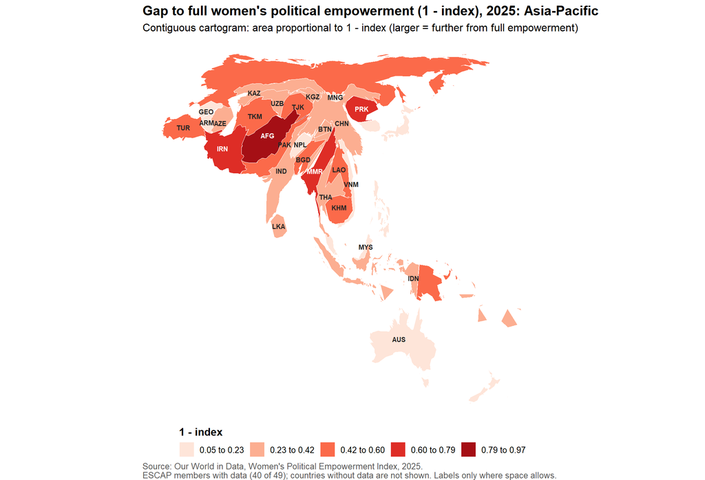

```r
library(cartogram)

# One feature per country (some come in several pieces), only those with data;
# simplified outlines keep the cartogram algorithm fast and stable
carto_in <- ap_data |>
  filter(!is.na(index)) |>
  mutate(gap = 1 - index) |>                              # distance from full empowerment (0 = best)
  group_by(Code, Entity, index, gap) |>
  summarise(.groups = "drop") |>
  st_make_valid() |>
  st_simplify(dTolerance = 2e4, preserveTopology = TRUE)

# Contiguous (Dougenik) cartogram: each country's AREA is made proportional to 1 - index
carto <- cartogram_cont(carto_in, weight = "gap", itermax = 15, maxSizeError = 1.3)

# Equal-interval classes of the gap: the global equal-interval breaks of the index, mirrored
br_gap <- 1 - rev(br_equal)
carto  <- carto |>
  mutate(cls = classify(gap, br_gap))

reds <- c("#fee5d9", "#fcae91", "#fb6a4a", "#de2d26", "#a50f15")

# Labels: one point inside the largest part of each deformed country, only where there is room
lab <- carto |>
  st_cast("POLYGON") |>
  suppressWarnings() |>
  mutate(part_m2 = as.numeric(st_area(geometry))) |>
  group_by(Code) |>
  slice_max(part_m2, n = 1, with_ties = FALSE) |>
  ungroup() |>
  filter(part_m2 > 1.5e11) |>                             # label countries larger than ~150,000 km2 on the map
  st_point_on_surface() |>
  suppressWarnings()
lab_xy <- st_coordinates(lab)
lab <- lab |>
  st_drop_geometry() |>
  mutate(x = lab_xy[, "X"], y = lab_xy[, "Y"],
         txt = ifelse(as.integer(cls) >= 4, "white", "grey15"))

ggplot() +
  geom_sf(data = carto, aes(fill = cls), colour = "white", linewidth = 0.25) +
  geom_text(data = lab, aes(x, y, label = Code, colour = txt), fontface = "bold", size = 2.6) +
  scale_fill_manual(values = reds, drop = FALSE,
                    name = "1 - index",
                    guide = guide_legend(nrow = 1, title.position = "top")) +
  scale_colour_identity() +
  labs(title = "Gap to full women's political empowerment (1 - index), 2025: Asia-Pacific",
       subtitle = "Contiguous cartogram: area proportional to 1 - index (larger = further from full empowerment)",
       caption = paste0("Source: Our World in Data, Women's Political Empowerment Index, 2025.\n",
                        "ESCAP members with data (", nrow(carto), " of ", length(ap_codes),
                        "); countries without data are not shown. Labels only where space allows.")) +
  map_theme
```